# Data Handling: Import, Cleaning and Visualisation

Exercise/Workshop 6: Visualisation

Prof. Dr. Ulrich Matter

21/12/2022

# Exercises

## Exercise A: Summary Stats and Data Display

Install and load the R package `nycflights13` and load `tidyverse`.

```r
# install and load packages
library(nycflights13)
library(tidyverse)
library(haven)
```

Loading the `nycflights13`-package automatically imports a large `data.frame`/`tibble` called `flights`. Have a look at the dimensions, data types, variables, and first few observations. Also use `str()` to get a summary overview over the structure of the dataset.

```r
flights
```

```
## # A tibble: 336,776 × 19
##     year month   day dep_time sched_…¹ dep_d…² arr_t…³ sched…⁴ arr_d…⁵ carrier flight tailnum origin
##    <int> <int> <int>    <int>    <int>   <dbl>   <int>   <int>   <dbl> <chr>    <int> <chr>   <chr>
##  1  2013     1     1      517      515       2     830     819      11 UA        1545 N14228  EWR
##  2  2013     1     1      533      529       4     850     830      20 UA        1714 N24211  LGA
##  3  2013     1     1      542      540       2     923     850      33 AA        1141 N619AA  JFK
##  4  2013     1     1      544      545      -1    1004    1022     -18 B6         725 N804JB  JFK
##  5  2013     1     1      554      600      -6     812     837     -25 DL         461 N668DN  LGA
##  6  2013     1     1      554      558      -4     740     728      12 UA        1696 N39463  EWR
##  7  2013     1     1      555      600      -5     913     854      19 B6         507 N516JB  EWR
##  8  2013     1     1      557      600      -3     709     723     -14 EV        5708 N829AS  LGA
##  9  2013     1     1      557      600      -3     838     846      -8 B6          79 N593JB  JFK
## 10  2013     1     1      558      600      -2     753     745       8 AA         301 N3ALAA  LGA
## # … with 336,766 more rows, 6 more variables: dest <chr>, air_time <dbl>, distance <dbl>,
## #   hour <dbl>, minute <dbl>, time_hour <dttm>, and abbreviated variable names ¹sched_dep_time,
## #   ²dep_delay, ³arr_time, ⁴sched_arr_time, ⁵arr_delay
```

```r
str(flights)
```

```
## tibble [336,776 × 19] (S3: tbl_df/tbl/data.frame)
##  $ year          : int [1:336776] 2013 2013 2013 2013 2013 2013 2013 2013 2013 2013 ...
##  $ month         : int [1:336776] 1 1 1 1 1 1 1 1 1 1 ...
##  $ day           : int [1:336776] 1 1 1 1 1 1 1 1 1 1 ...
##  $ dep_time      : int [1:336776] 517 533 542 544 554 554 555 557 557 558 ...
##  $ sched_dep_time: int [1:336776] 515 529 540 545 600 558 600 600 600 600 ...
##  $ dep_delay     : num [1:336776] 2 4 2 -1 -6 -4 -5 -3 -3 -2 ...
##  $ arr_time      : int [1:336776] 830 850 923 1004 812 740 913 709 838 753 ...
##  $ sched_arr_time: int [1:336776] 819 830 850 1022 837 728 854 723 846 745 ...
##  $ arr_delay     : num [1:336776] 11 20 33 -18 -25 12 19 -14 -8 8 ...
##  $ carrier       : chr [1:336776] "UA" "UA" "AA" "B6" ...
##  $ flight        : int [1:336776] 1545 1714 1141 725 461 1696 507 5708 79 301 ...
##  $ tailnum       : chr [1:336776] "N14228" "N24211" "N619AA" "N804JB" ...
##  $ origin        : chr [1:336776] "EWR" "LGA" "JFK" "JFK" ...
##  $ dest          : chr [1:336776] "IAH" "IAH" "MIA" "BQN" ...
##  $ air_time      : num [1:336776] 227 227 160 183 116 150 158 53 140 138 ...
##  $ distance      : num [1:336776] 1400 1416 1089 1576 762 ...
##  $ hour          : num [1:336776] 5 5 5 5 6 5 6 6 6 6 ...
##  $ minute        : num [1:336776] 15 29 40 45 0 58 0 0 0 0 ...
##  $ time_hour     : POSIXct[1:336776], format: "2013-01-01 05:00:00" "2013-01-01 05:00:00" "2013-01-01 05:00:00" ...
```

The dataset is on flights departing from New York City in 2013 (original data provided by the US Bureau of Transportation Statistics). You can have a closer look at what the variables describe by looking at the provided documentation: `?flights`.

The following table summarises and nicely displays one of the key variables in the dataset. Use your data preparation, data analysis, and data display skills to reproduce the table (output in either HTML, LaTeX/PDF, or Word format).

Summary Statistics: Air time (in minutes) for flights between NYC and BOS (2013)

| Month | Mean | Median | Std. Deviation | Min. Value | Max. Value |
| --- | --- | --- | --- | --- | --- |
| January | 39.05 | 39 | 4.99 | 23 | 81 |
| February | 38.72 | 38 | 4.62 | 30 | 86 |
| March | 39.57 | 39 | 5.80 | 21 | 82 |
| April | 38.08 | 37 | 4.93 | 29 | 68 |
| May | 39.28 | 39 | 4.72 | 29 | 82 |
| June | 38.76 | 38 | 5.20 | 29 | 112 |
| July | 39.08 | 38 | 5.96 | 30 | 99 |
| August | 39.58 | 39 | 4.28 | 30 | 66 |
| September | 39.09 | 39 | 4.00 | 26 | 70 |
| October | 38.60 | 38 | 4.50 | 31 | 63 |
| November | 38.95 | 39 | 4.19 | 30 | 62 |
| December | 38.55 | 38 | 5.61 | 30 | 73 |

Hint: The `lubridate` package might be helpful to parse the month column. The function `months()` (base package) extracts the months from `Date` variables.

## Exercise B: R Graphics with `ggplot2`

Again working with the `flights` dataset, reproduce the following figure with `ggplot()`. Hint: Some preparations are needed (filtering, formatting, and removal of missing values). Note that the figure only compares flights in December with flights in June for the destinations “BOS”, “ORD”, and “LAX”.

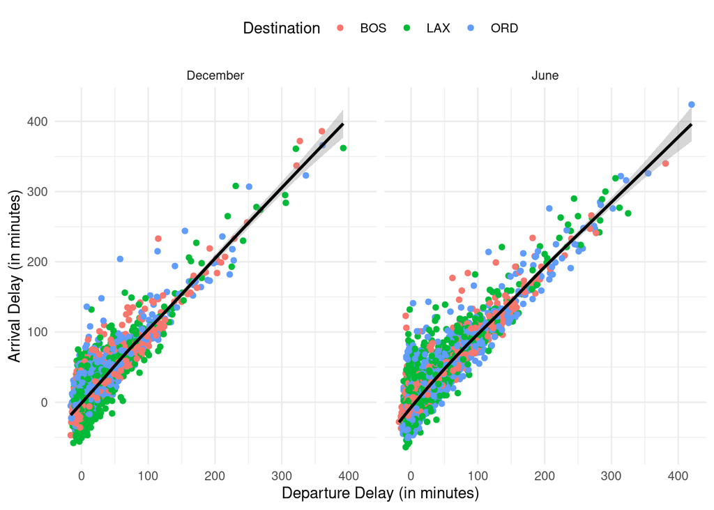

## Exercise C: `ggplot2` challenge on COVID

Plot the cumulative confirmed COVID cases (on a log scale) for China, France, Germany, Italy, Switzerland, the United Kingdom, and the US. Use John Hopkinds GitHub data. Your graph will look like the example shown below.

Hint: download the data as follows:

```r
confirmedraw <- read.csv("https://raw.githubusercontent.com/CSSEGISandData/COVID-19/
                         master/csse_covid_19_data/csse_covid_19_time_series/
                         time_series_covid19_confirmed_global.csv")
```

Various cleaning steps are required (gathering data, reformatting date values, calculating the cumulative sum of cases, …). For plotting, replace the dates by numbers (the first date is day 1, the second date day 2, etc. – as shown in the graph). This exercise is inspired by https://mdl.library.utoronto.ca/technology/tutorials/covid-19-data-r.

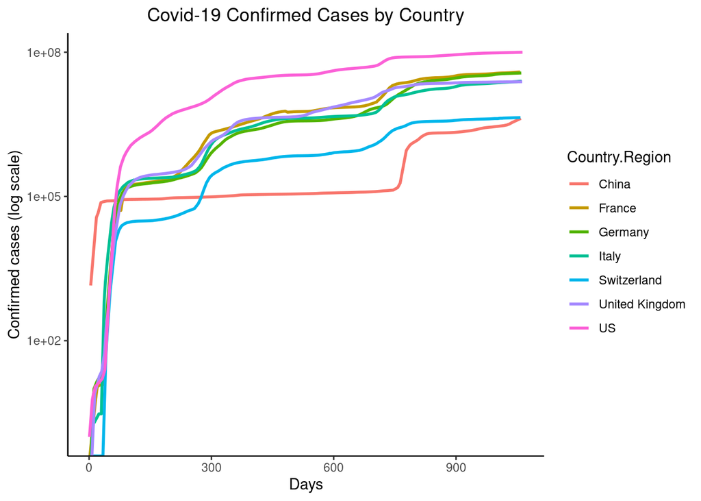

# Christmas Gift Exercise (advanced)

Two PhD students, after a long evening, were arguing about fundamental research questions. Talking about drug restrictions, one of the two was convinced that the liberalization of private drug use (such as cannabis and harder narcotics) would naturally lead to an increase in violence and in episodes of (collective) psychosis. The only way to see if this claim holds water is to find data that would confirm this hypothesis. The two economists then gathered the two following datasets:

- To measure psychotic episodes, they used data from the National UFO Reporting Center, which collects data on each reported UFO seeing across the world. The data are available here: http://www.nuforc.org/webreports.html. The data are ready for use in the file `ufodata_exercise.csv`, which contains the following variables:
  - `State.name` and `State.abbr` give the US State identifier;
  - `year` gives the year;
  - `total.views.year` gives the number of UFO seeings per year and per State
- To measure drug liberalization policies, they scraped the Wikipedia website to get a timeline of cannabis legalization dates across US States. The data was obtained here: https://en.wikipedia.org/wiki/Legality_of_cannabis_by_U.S._jurisdiction. The data are ready for use in the file `pot_exercise.csv`, which contains the following variables:
  - `state` gives the US State identifier;
  - `year` gives the year;
  - `Legalization_medical` is 1 if the use of cannabis for medical purposes was legalized in the State-year, and 0 otherwise.

The hypothesis is the following: the legalization of cannabis for medical purposes leads to an increase in hallucinations and episodes of “psychosis”. These episodes of psychosis might translate into the number of UFO seeings. Since cannabis was not legalized at the same time in all States (“staggered” introduction), we can compare States which have introduced legal cannabis for medical purposes with States which did not.

1. First, import the two datasets `pot_exercise.csv` and `ufodata_exercise.csv` found on Canvas. Explore the datasets, and merge the two datasets using `left_join(pot_exercise, ufodata_exercise, by = c("state" = "State.name", "year"))` into a new dataframe called `data`. Clean the new dataset.**

```r
pot <- read_csv("../data/pot_exercise.csv")
ufodata <- read_csv("../data/ufodata_exercise.csv")

# Merge
data <- left_join(pot, ufodata,
                  by = c("state" = "State.name", "year"))

# Cleaning: total.views.year is NA for many observations. Remove these observations.
data <- data[!is.na(data$total.views.year), ]
```

2. You want to see whether the number of UFO seeings in States which have legalized cannabis for medical use is larger than in States which have not. You consider the following linear regression model:
   $$\text{total.views.year} = \alpha + \beta
   \text{Legalization\_medical} + u,$$
   where *total.views.year* is the number of UFO seeings, and *Legalization_medical* indicates whether the State has legalized cannabis for medical use. $u$ is an error term. Estimate the regression and save your regression model in an object called `regression`.

```r
regression <- lm(total.views.year ~ Legalization_medical, data = data)
summary(regression)
```

```
##
## Call:
## lm(formula = total.views.year ~ Legalization_medical, data = data)
##
## Residuals:
##    Min     1Q Median     3Q    Max
## -89.07 -45.46 -34.46   9.29 819.54
##
## Coefficients:
##                      Estimate Std. Error t value Pr(>|t|)
## (Intercept)            49.463      1.809  27.336  < 2e-16 ***
## Legalization_medical   48.602     12.767   3.807 0.000144 ***
## ---
## Signif. codes:  0 '***' 0.001 '**' 0.01 '*' 0.05 '.' 0.1 ' ' 1
##
## Residual standard error: 85.72 on 2288 degrees of freedom
## Multiple R-squared:  0.006294,   Adjusted R-squared:  0.00586
## F-statistic: 14.49 on 1 and 2288 DF,  p-value: 0.0001444
```

3. Use `ggplot()` to plot the coefficient estimates of Legalization_medical and corresponding confidence intervals. Interpret the results.

*Hint (1)*: To draw a plot of regression estimates, transform the regression output into a tibble specifying that you need 95% confidence intervals. A handy way to do this is to use the command `tidy()`from the `broom` package (you’ll need to load the package accordingly). The command `tidy()` takes an `lm` object as its argument, and “extracts” all the important information about the linear regression stored in the `lm` object. It works like `summary()`, but it delivers the information in a tibble: each parameter of the linear regression (here, $\alpha$ and $\beta$) is stored as an observation (row), which contains values for the coefficient, the standard errors, the $t$ statistics, and the p-value. Confidence intervals are optional, and must be called with the option `conf.int = T`. You can compare the result of `summary(regression)` above with the result of `tidy()` right below.

```r
library(broom)
summary.regression <- tidy(regression, conf.int = T, conf.level = 0.95)
summary.regression
```

```
## # A tibble: 2 × 7
##   term                 estimate std.error statistic   p.value conf.low conf.high
##   <chr>                   <dbl>     <dbl>     <dbl>     <dbl>    <dbl>     <dbl>
## 1 (Intercept)              49.5      1.81     27.3  1.29e-142     45.9      53.0
## 2 Legalization_medical     48.6     12.8       3.81 1.44e-  4     23.6      73.6
```

*Hint (2)* To draw the graph, you will need `geom_point()` to draw your point estimate, `geom_errorbar()` to draw the confidence intervals, and `geom_hline()` to draw the horizontal zero line. Note that you don’t need to draw the coefficient for the constant.)

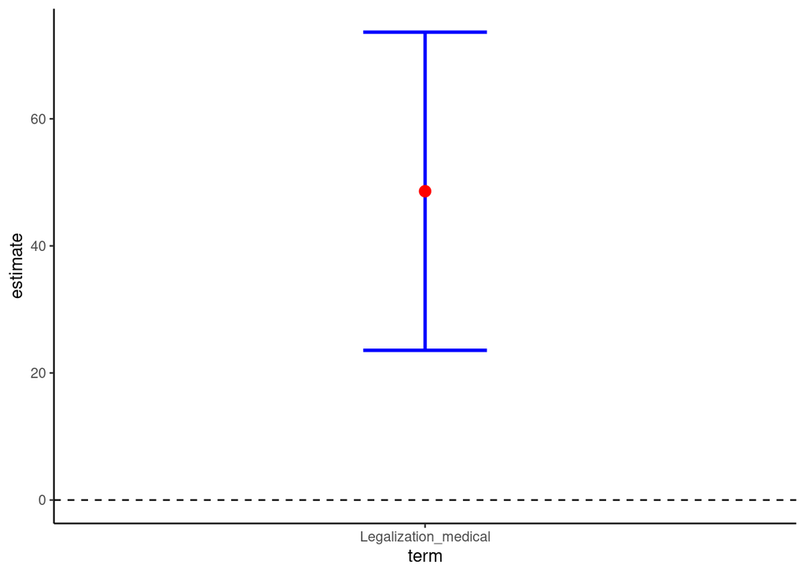

```r
# We are not interested in the constant:
summary.regression <- filter(summary.regression, term == "Legalization_medical")

ggplot(summary.regression, aes(x = term, y = estimate)) +
  geom_errorbar(aes(ymin = conf.low, ymax = conf.high), width=0.2, size=1, color="blue") +
  geom_point(size = 3, color = "red") +
  geom_hline(yintercept = 0, linetype = 2) +
  theme_classic()
```

**Interpretation**: having cannabis legalized increases the average number of UFO seeings by 48.60. This effect is statistically significant at the 95% level (the confidence intervals do not touch the 0-line).

4. In this analysis, we did not take into account the fact that States are heterogeneous, and that our effect could be driven only by the fact that States with lots of UFO seeings are also States that would be more inclined to have cannabis legalized. Perform the same analysis as before, but this time include State and year controls in your regression:
   $$total.views.year = \alpha +
   \beta *\text{Legalization\_medical} + \delta *\text{as.factor(state)} +
   \gamma *\text{as.factor(year)} + u,$$
   . This model is called a “Difference-in-Difference” model with many groups and time periods in econometrics. Look at the coefficient of `Legalization_medical`. What happened?

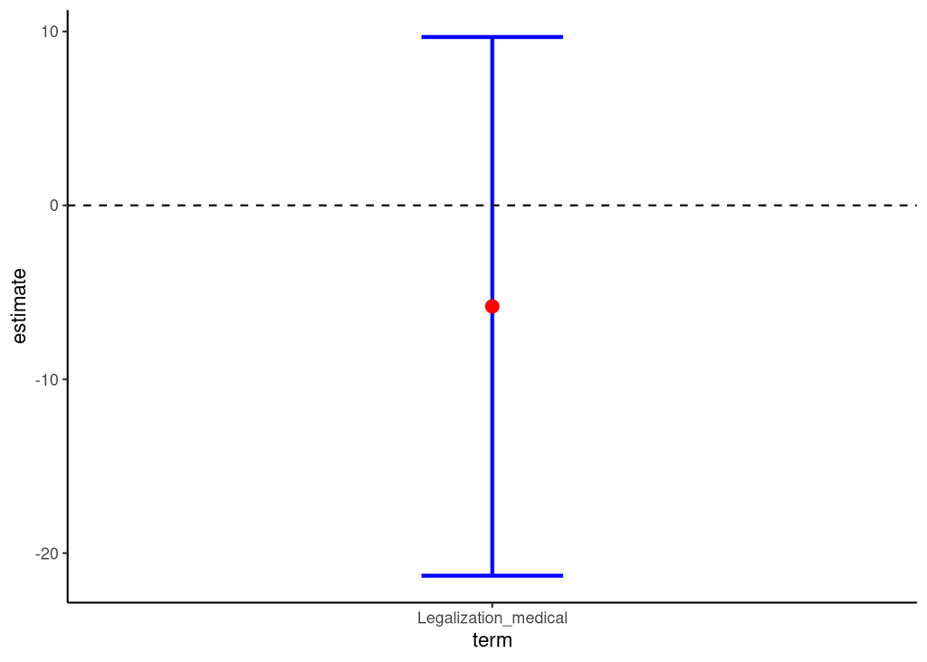

```r
regression_2 <- lm(total.views.year ~ Legalization_medical + as.factor(state) + as.factor(year), data = data)

summary.regression_2 <- tidy(regression_2, conf.int = T, conf.level = 0.95)

# We are not interested in the constant:
summary.regression_2 <- filter(summary.regression_2, term == "Legalization_medical")

ggplot(summary.regression_2, aes(x = term, y = estimate)) +
  geom_errorbar(aes(ymin = conf.low, ymax = conf.high), width=0.2, size=1, color="blue") +
  geom_point(size = 3, color = "red") +
  geom_hline(yintercept = 0, linetype = 2) +
  theme_classic()
```

This time, the effect is negative and not significant anymore. It means that the effect we obtained in the first regression was mostly due to the fact that the number of UFO seeings was more related to particular States rather than to the cannabis legalization.

# Advanced visualization exercise

## `ggplot2` challenge on corruption

Import the dataset `EconomistData.csv` (provided in `data.zip`) to R. The underlying data sources have been used by The Economist (2nd December 2011, [‘Corrosive Corruption’](https://www.economist.com/graphic-detail/2011/12/02/corrosive-corruption)) to generate the following figure:

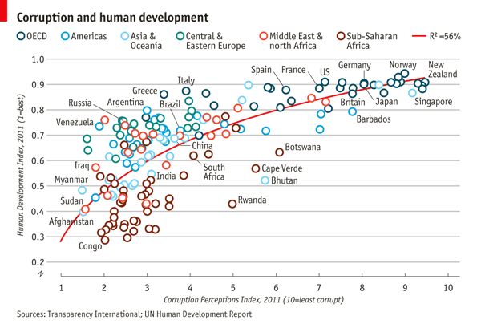

Given the data, the challenge is to reproduce (or get as close to) the original figure with `ggplot2`.